# Factors of liver fibrosis

AG

March 31, 2019

## 3.1 Клиническая характеристика больных

### Половозрастное соотношение

Средний возраст 56.530303; медиана 58

число М и Ж

```
## # A tibble: 2 x 2
##   `(0=F; 1=M)`     N
##          <dbl> <int>
## 1            0    80
## 2            1    52
```

Число М и Ж до 44 лет (включительно)

```
## # A tibble: 2 x 2
##   `(0=F; 1=M)`     N
##          <dbl> <int>
## 1            0     5
## 2            1    16
```

Число М и Ж от 45 до 60 лет (включительно)

```
## # A tibble: 2 x 2
##   `(0=F; 1=M)`     N
##          <dbl> <int>
## 1            0    38
## 2            1    24
```

Число М и Ж от 61 до 75 лет (включительно)

```
## # A tibble: 2 x 2
##   `(0=F; 1=M)`     N
##          <dbl> <int>
## 1            0    32
## 2            1    12
```

```
## # A tibble: 1 x 2
##   `(0=F; 1=M)`     N
##          <dbl> <int>
## 1            0     5
```

Распределение по возрасту и полу

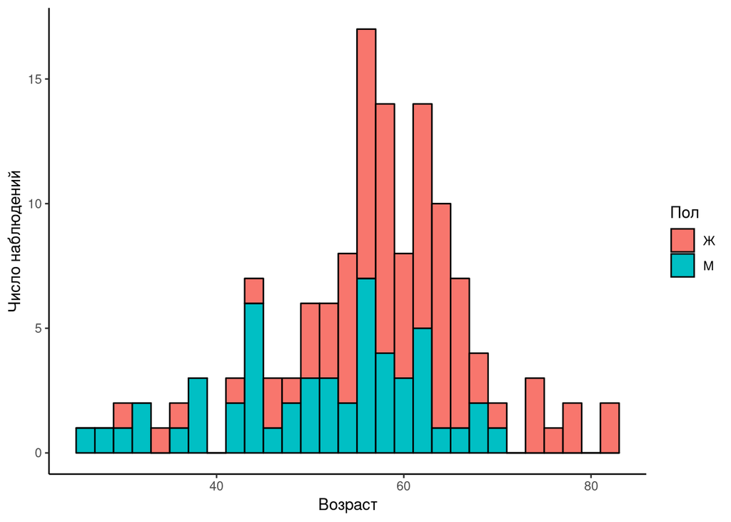

### Результаты лабораторных проб

```
##
##  Kruskal-Wallis rank sum test
##
## data:  sample(SD$Cholesterol, length(noSD$Cholesterol)) and noSD$Cholesterol
## Kruskal-Wallis chi-squared = 26.387, df = 26, p-value = 0.442
```

### Специфические белки

### Биохимический анализ крови

## 3.2. Характер распределения стадий НАЖБП

### Стадии НАЖБП по клиническому диагнозу

#### A = 0

```
##           A_
## group       0  1
##   контроль 12 19
##   СД       40 92
```

```
##
##  2-sample test for equality of proportions with continuity
##  correction
##
## data:  .
## X-squared = 0.47554, df = 1, p-value = 0.4905
## alternative hypothesis: two.sided
## 95 percent confidence interval:
##  -0.1243878  0.2925207
## sample estimates:
##    prop 1    prop 2
## 0.3870968 0.3030303
```

#### A > 0 & Fscan == 4

```
##           A_0_Fscan_4
## group      >0&4 others
##   контроль    1     28
##   СД         27    105
```

```
##
##  2-sample test for equality of proportions with continuity
##  correction
##
## data:  .
## X-squared = 3.6758, df = 1, p-value = 0.05521
## alternative hypothesis: two.sided
## 95 percent confidence interval:
##  -0.28672302 -0.05340237
## sample estimates:
##     prop 1     prop 2
## 0.03448276 0.20454545
```

#### Fscan = 4

```
##           Fscan_
## group        0   4
##   контроль  27   2
##   СД       103  29
```

```
##
##  2-sample test for equality of proportions with continuity
##  correction
##
## data:  .
## X-squared = 2.5727, df = 1, p-value = 0.1087
## alternative hypothesis: two.sided
## 95 percent confidence interval:
##  0.01353689 0.28792602
## sample estimates:
##    prop 1    prop 2
## 0.9310345 0.7803030
```

### Стадии стеатоза

#### S1

```
##           S1_
## group       S1 S2-3
##   контроль   8   22
##   СД         9  121
```

```
##
##  2-sample test for equality of proportions with continuity
##  correction
##
## data:  .
## X-squared = 8.0347, df = 1, p-value = 0.004589
## alternative hypothesis: two.sided
## 95 percent confidence interval:
##  0.01277455 0.38209725
## sample estimates:
##     prop 1     prop 2
## 0.26666667 0.06923077
```

#### S2

```
##           S2_
## group      S1,3  S2
##   контроль   21   9
##   СД        110  20
```

```
##
##  2-sample test for equality of proportions with continuity
##  correction
##
## data:  .
## X-squared = 2.5929, df = 1, p-value = 0.1073
## alternative hypothesis: two.sided
## 95 percent confidence interval:
##  -0.34198614  0.04967844
## sample estimates:
##    prop 1    prop 2
## 0.7000000 0.8461538
```

#### S3

```
##           S3_
## group      S1-2 S3
##   контроль   17 13
##   СД         33 97
```

```
##
##  2-sample test for equality of proportions with continuity
##  correction
##
## data:  .
## X-squared = 9.694, df = 1, p-value = 0.001849
## alternative hypothesis: two.sided
## 95 percent confidence interval:
##  0.09984989 0.52579114
## sample estimates:
##    prop 1    prop 2
## 0.5666667 0.2538462
```

### Стадии фиброза

#### F0

```
##         F_0
## Fscan_0   0 others
##   0      19     24
##   others 20     69
```

```
##
##  2-sample test for equality of proportions with continuity
##  correction
##
## data:  .
## X-squared = 5.5653, df = 1, p-value = 0.01832
## alternative hypothesis: two.sided
## 95 percent confidence interval:
##  0.02798891 0.40629382
## sample estimates:
##    prop 1    prop 2
## 0.4418605 0.2247191
```

#### F1

```
##         F_1
## Fscan_1   1 others
##   1      14     14
##   others 25     79
```

```
##
##  2-sample test for equality of proportions with continuity
##  correction
##
## data:  .
## X-squared = 5.9502, df = 1, p-value = 0.01472
## alternative hypothesis: two.sided
## 95 percent confidence interval:
##  0.03435872 0.48487205
## sample estimates:
##    prop 1    prop 2
## 0.5000000 0.2403846
```

#### F2

```
##         F_2
## Fscan_2   2 others
##   2       5     14
##   others 20     93
```

```
##
##  2-sample test for equality of proportions with continuity
##  correction
##
## data:  .
## X-squared = 0.32547, df = 1, p-value = 0.5683
## alternative hypothesis: two.sided
## 95 percent confidence interval:
##  -0.1547076  0.3270411
## sample estimates:
##    prop 1    prop 2
## 0.2631579 0.1769912
```

#### F3

```
##         F_3
## Fscan_3    3 others
##   3        5      8
##   others   4    115
```

```
##
##  2-sample test for equality of proportions with continuity
##  correction
##
## data:  .
## X-squared = 17.538, df = 1, p-value = 2.817e-05
## alternative hypothesis: two.sided
## 95 percent confidence interval:
##  0.0419017 0.6601022
## sample estimates:
##     prop 1     prop 2
## 0.38461538 0.03361345
```

#### F4

```
##         F_4
## Fscan_4    4 others
##   4       18     11
##   others   2    101
```

```
##
##  2-sample test for equality of proportions with continuity
##  correction
##
## data:  .
## X-squared = 59.045, df = 1, p-value = 1.541e-14
## alternative hypothesis: two.sided
## 95 percent confidence interval:
##  0.4005800 0.8019643
## sample estimates:
##     prop 1     prop 2
## 0.62068966 0.01941748
```

### Стадии фиброза по группам

#### F0-2

```
##         F_02
## Fscan_02 0-2 others
##   0-2     88      2
##   others  15     27
```

```
##
##  2-sample test for equality of proportions with continuity
##  correction
##
## data:  .
## X-squared = 60.774, df = 1, p-value = 6.402e-15
## alternative hypothesis: two.sided
## 95 percent confidence interval:
##  0.4550981 0.7861718
## sample estimates:
##    prop 1    prop 2
## 0.9777778 0.3571429
```

#### F3-4

```
##         F_34
## Fscan_34 3-4 others
##   3-4     27     15
##   others   2     88
```

```
##
##  2-sample test for equality of proportions with continuity
##  correction
##
## data:  .
## X-squared = 60.774, df = 1, p-value = 6.402e-15
## alternative hypothesis: two.sided
## 95 percent confidence interval:
##  0.4550981 0.7861718
## sample estimates:
##     prop 1     prop 2
## 0.64285714 0.02222222
```

### Влияние какого-либо фактора на рзвитие тяжелого фиброза (F3-F4)

#### F

Результаты теста Краскела-Уоллиса (F)

| columns | число.наблюдений.ТФ | число.наблюдений.ЛФ | среднее.ТФ | среднее.ЛФ | медиана.ТФ | медиана.ЛФ | хи.квадрат | p.value | значимость |
| --- | --- | --- | --- | --- | --- | --- | --- | --- | --- |
| F | 29 | 103 | 3.68965517241379 | 0.864077669902913 | 4 | 1 | 71.8383570331798 | 0.0000000 | да |
| F1 | 29 | 100 | 0.78 | 0.2773 | 0.8 | 0.275 | 66.9532073635553 | 0.0000000 | да |
| A2M | 29 | 103 | 3.31034482758621 | 1.79708737864078 | 3.02 | 1.72 | 46.3004836583348 | 0.0000000 | да |
| Fscan | 29 | 103 | 3.48275862068966 | 1.16504854368932 | 4 | 1 | 42.7669605521826 | 0.0000000 | да |
| F-kPa | 29 | 103 | 15.2068965517241 | 7.2873786407767 | 13 | 6.1 | 39.072726547618 | 0.0000000 | да |
| А | 29 | 103 | 2.24137931034483 | 0.961165048543689 | 3 | 1 | 28.3069992267513 | 0.0000001 | да |
| A1 | 29 | 100 | 0.584827586206897 | 0.29208 | 0.64 | 0.26 | 25.0002366620586 | 0.0000006 | да |
| AST | 29 | 103 | 70.0413793103448 | 40.3291262135922 | 58 | 29.5 | 22.5577227485938 | 0.0000020 | да |
| Plt | 29 | 99 | 182 | 232.454545454545 | 180 | 222 | 15.1020055835534 | 0.0001019 | да |
| GGT | 29 | 103 | 125.706896551724 | 66.1719417475728 | 116 | 46 | 14.9091846369741 | 0.0001128 | да |
| GG | 29 | 103 | 1.14910344827586 | 1.59184466019417 | 1.14 | 1.5 | 11.5199313664802 | 0.0006885 | да |
| Age | 29 | 103 | 62.1034482758621 | 54.9611650485437 | 62 | 57 | 11.0962034841267 | 0.0008650 | да |
| BB | 29 | 103 | 26.3758620689655 | 14.847572815534 | 16 | 12 | 9.95833402459517 | 0.0016012 | да |
| alcohol | 24 | 63 | 0.208333333333333 | 0.0158730158730159 | 0 | 0 | 9.9105183225554 | 0.0016434 | да |
| ALT | 29 | 103 | 92.7586206896552 | 59.8058252427184 | 77 | 46 | 7.68982472663701 | 0.0055533 | да |
| F b | 3 | 12 | 3.33333333333333 | 0.75 | 3 | 0.5 | 6.59817351598174 | 0.0102083 | да |
| IQR | 29 | 103 | 2.43724137931034 | 1.82718446601942 | 2 | 1.1 | 6.13773998020737 | 0.0132326 | да |
| AA1 | 29 | 103 | 1.23551724137931 | 1.38106796116505 | 1.23 | 1.38 | 5.92959937664814 | 0.0148886 | да |
| prothrombin | 22 | 54 | 82.0909090909091 | 89.4962962962963 | 82.5 | 90 | 5.20532568023116 | 0.0225178 | да |
| splenomegaly | 25 | 64 | 0.48 | 0.234375 | 0 | 0 | 5.07448924731185 | 0.0242804 | да |
| A b | 3 | 12 | 1.33333333333333 | 0.75 | 1 | 1 | 2.8125 | 0.0935325 | нет |
| (0=F; 1=M) | 29 | 103 | 0.517241379310345 | 0.359223300970874 | 1 | 0 | 2.34869562978031 | 0.1253879 | нет |
| Growth | 29 | 103 | 1.70275862068966 | 1.67747572815534 | 1.7 | 1.66 | 2.32174674415639 | 0.1275767 | нет |
| S1 | 27 | 99 | 0.755925925925926 | 0.742525252525252 | 0.83 | 0.78 | 2.14290891462495 | 0.1432301 | нет |
| CAP | 7 | 34 | 290.285714285714 | 256.5 | 293 | 262.5 | 1.78282833468525 | 0.1818024 | нет |
| N | 28 | 102 | 1.35714285714286 | 1.2156862745098 | 1 | 1 | 1.34611120385352 | 0.2459591 | нет |
| steatosis | 25 | 65 | 0.64 | 0.538461538461538 | 1 | 1 | 0.749669335189685 | 0.3865809 | нет |
| CAP-S | 8 | 35 | 2.375 | 2.05714285714286 | 3 | 2 | 0.691791744840535 | 0.4055556 | нет |
| N1 | 27 | 99 | 0.575925925925926 | 0.553030303030303 | 0.5 | 0.5 | 0.58957496698377 | 0.4425835 | нет |
| BMI | 29 | 103 | 32.8862068965517 | 33.626213592233 | 32 | 33.1 | 0.47608495424072 | 0.4902010 | нет |
| Hb1Ac | 12 | 27 | 7.425 | 7.92222222222222 | 7.1 | 7.6 | 0.469891436688312 | 0.4930371 | нет |
| S b | 3 | 13 | 2.33333333333333 | 2 | 2 | 2 | 0.262207357859535 | 0.6086077 | нет |
| Cholesterol | 29 | 103 | 5.73793103448276 | 5.53572815533981 | 5.6 | 5.62 | 0.186191340946212 | 0.6661056 | нет |
| Weight | 29 | 103 | 96.0862068965517 | 94.647572815534 | 94 | 94 | 0.137738931351109 | 0.7105392 | нет |
| Trigl | 29 | 103 | 2.15758620689655 | 2.38320388349515 | 2 | 1.95 | 0.135611372078144 | 0.7126835 | нет |
| S | 28 | 102 | 2.57142857142857 | 2.62745098039216 | 3 | 3 | 0.0883861157745816 | 0.7662390 | нет |
| Glu | 29 | 103 | 7.94034482758621 | 8.90660194174757 | 7.4 | 7.3 | 0.0832965824872217 | 0.7728787 | нет |

#### Fscan

Результаты теста Краскела-Уоллиса (Fscan)

| columns | число.наблюдений.ТФ | число.наблюдений.ЛФ | среднее.ТФ | среднее.ЛФ | медиана.ТФ | медиана.ЛФ | хи.квадрат | p.value | значимость |
| --- | --- | --- | --- | --- | --- | --- | --- | --- | --- |
| Fscan | 42 | 90 | 3.69047619047619 | 0.733333333333333 | 4 | 1 | 90.5706621143763 | 0.0000000 | да |
| F-kPa | 42 | 90 | 15.3928571428571 | 6.05666666666667 | 13.35 | 5.85 | 85.3139047400268 | 0.0000000 | да |
| F | 42 | 90 | 2.88095238095238 | 0.833333333333333 | 3 | 1 | 52.0428935606851 | 0.0000000 | да |
| F1 | 42 | 87 | 0.632380952380952 | 0.273448275862069 | 0.71 | 0.25 | 46.3342529909306 | 0.0000000 | да |
| A2M | 42 | 90 | 2.83619047619048 | 1.79977777777778 | 2.67 | 1.725 | 31.2420634465064 | 0.0000000 | да |
| IQR | 42 | 90 | 3.0447619047619 | 1.45555555555556 | 2.25 | 1.1 | 27.9366542032448 | 0.0000001 | да |
| А | 42 | 90 | 1.88095238095238 | 0.944444444444444 | 2 | 1 | 20.29438227112 | 0.0000066 | да |
| A1 | 42 | 87 | 0.501190476190476 | 0.288712643678161 | 0.475 | 0.25 | 17.8771433498938 | 0.0000236 | да |
| GGT | 42 | 90 | 110.678571428571 | 64.5856666666667 | 89.5 | 39.05 | 14.3016643127203 | 0.0001557 | да |
| Plt | 42 | 86 | 193.119047619048 | 234.651162790698 | 185 | 222.5 | 14.0545118242765 | 0.0001776 | да |
| BB | 42 | 90 | 23.1166666666667 | 14.7033333333333 | 15.5 | 11.15 | 12.7849201990792 | 0.0003494 | да |
| GG | 42 | 90 | 1.232 | 1.61711111111111 | 1.21 | 1.51 | 11.7818108932741 | 0.0005981 | да |
| AST | 42 | 90 | 61.4333333333333 | 40.0544444444444 | 50.5 | 29 | 10.8475331355674 | 0.0009893 | да |
| prothrombin | 30 | 46 | 80.7266666666667 | 91.6739130434783 | 83.5 | 90 | 7.61998002491822 | 0.0057725 | да |
| splenomegaly | 34 | 55 | 0.470588235294118 | 0.2 | 0 | 0 | 7.19758240213657 | 0.0073002 | да |
| F b | 3 | 12 | 3.33333333333333 | 0.75 | 3 | 0.5 | 6.59817351598174 | 0.0102083 | да |
| alcohol | 33 | 54 | 0.151515151515152 | 0.0185185185185185 | 0 | 0 | 5.57764891715501 | 0.0181911 | да |
| ALT | 42 | 90 | 86.45 | 57.99 | 70 | 45.5 | 5.31889626087909 | 0.0210954 | да |
| Age | 42 | 90 | 59.0952380952381 | 55.3333333333333 | 59 | 57 | 3.12540385416106 | 0.0770808 | нет |
| (0=F; 1=M) | 42 | 90 | 0.5 | 0.344444444444444 | 0.5 | 0 | 2.88032051282058 | 0.0896682 | нет |
| A b | 3 | 12 | 1.33333333333333 | 0.75 | 1 | 1 | 2.8125 | 0.0935325 | нет |
| N | 41 | 89 | 1.34146341463415 | 1.20224719101124 | 1 | 1 | 1.66465505131187 | 0.1969760 | нет |
| Weight | 42 | 90 | 97.8452380952381 | 93.6188888888889 | 98.5 | 94 | 1.63981618628778 | 0.2003507 | нет |
| Hb1Ac | 17 | 22 | 7.31176470588235 | 8.12272727272727 | 7.1 | 7.65 | 1.3516791530662 | 0.2449848 | нет |
| AA1 | 42 | 90 | 1.31547619047619 | 1.36477777777778 | 1.27 | 1.365 | 1.20872181000521 | 0.2715854 | нет |
| CAP | 9 | 32 | 284.666666666667 | 255.96875 | 291 | 262.5 | 1.08243148891604 | 0.2981543 | нет |
| N1 | 40 | 86 | 0.57625 | 0.549418604651163 | 0.5 | 0.5 | 0.997448962003336 | 0.3179286 | нет |
| Growth | 42 | 90 | 1.69357142857143 | 1.67811111111111 | 1.7 | 1.67 | 0.863189068449988 | 0.3528478 | нет |
| steatosis | 34 | 56 | 0.617647058823529 | 0.535714285714286 | 1 | 1 | 0.571922886801795 | 0.4494958 | нет |
| BMI | 42 | 90 | 33.9904761904762 | 33.2177777777778 | 33.35 | 32.85 | 0.519666197528001 | 0.4709841 | нет |
| Glu | 42 | 90 | 8.08738095238095 | 8.97755555555556 | 7.45 | 7.3 | 0.481535919380776 | 0.4877274 | нет |
| CAP-S | 10 | 33 | 2.3 | 2.06060606060606 | 3 | 2 | 0.473295809881182 | 0.4914748 | нет |
| S1 | 40 | 86 | 0.7615 | 0.737906976744186 | 0.79 | 0.8 | 0.402851285807696 | 0.5256204 | нет |
| S b | 3 | 13 | 2.33333333333333 | 2 | 2 | 2 | 0.262207357859535 | 0.6086077 | нет |
| Trigl | 42 | 90 | 2.18785714285714 | 2.40166666666667 | 2.035 | 1.94 | 0.245935947166707 | 0.6199514 | нет |
| S | 41 | 89 | 2.65853658536585 | 2.59550561797753 | 3 | 3 | 0.0744636978318409 | 0.7849452 | нет |
| Cholesterol | 42 | 90 | 5.62952380952381 | 5.55711111111111 | 5.59 | 5.675 | 0.0658085309046398 | 0.7975403 | нет |

## 3.3.3 Сравнение чувствительности и специфичности Fscan и Fв выявлении тяжелого фиброза F3-4

Результаты корреляционного анализа по методу Кендалла

| Корреляция | z.score | tau | p.value |
| --- | --- | --- | --- |
| Fb-Fscan | 3.076493 | 0.6166983 | 0.0020945 |
| Fb-F | 2.363957 | 0.4564170 | 0.0180809 |

Отсюда мы можем заключить, что Fscan лучше соответствует (предсказывает) Fb, чем F, так как параметр tau 0.62 > 0.46.

Результаты корреляционного анализа по методу Спирмена

| Корреляция | S.score | rho | p.value |
| --- | --- | --- | --- |
| Fb-Fscan | 442.9150 | 0.6669812 | 0.0013174 |
| Fb-F | 672.0304 | 0.4947140 | 0.0265867 |

Выводы те же.

## 4.1 Влияние течения СД на развитие ФП у б-х НАЖБП, СД ожирением

### 4.1.1. Сравнить средний ФП в группе СД и без СД

**F-max**

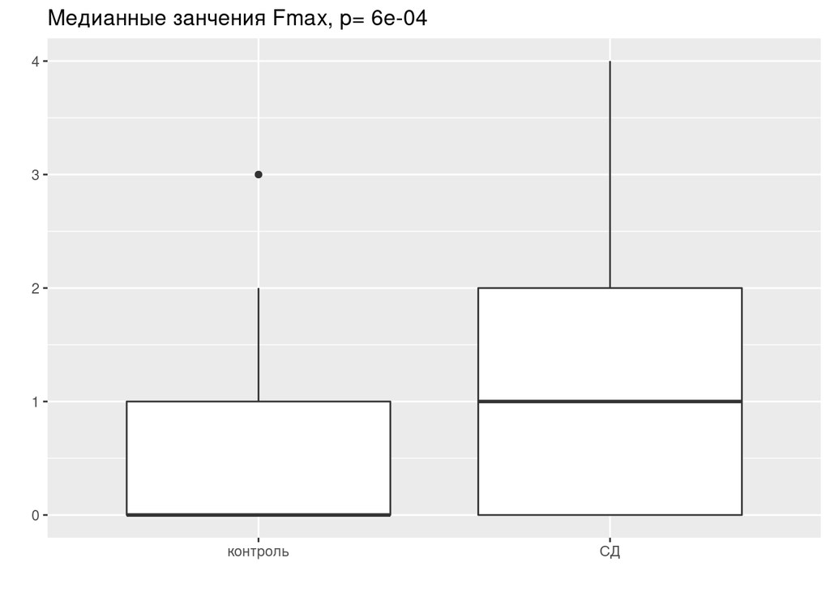

```
##
##  Kruskal-Wallis rank sum test
##
## data:  df$F and df$group
## Kruskal-Wallis chi-squared = 11.849, df = 1, p-value = 0.0005768
```

**Fscan**

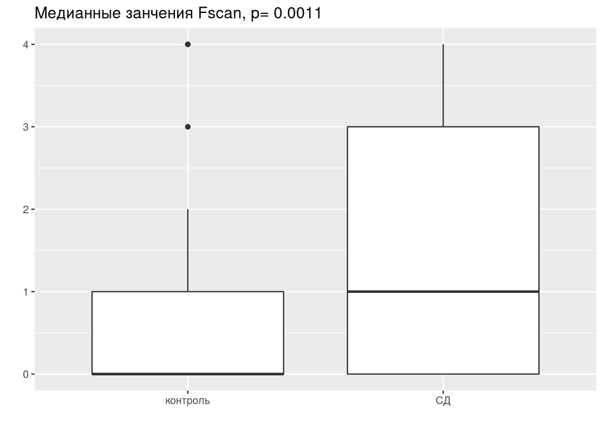

```
##
##  Kruskal-Wallis rank sum test
##
## data:  df$Fscan and df$group
## Kruskal-Wallis chi-squared = 10.717, df = 1, p-value = 0.001062
```

### 4.1.3. По терапии Сахарного диабета (СД). Сравнить терапию СД в группе F0-2 и F3-4

```
## # A tibble: 2 x 2
##   Fmax.group     n
##   <fct>      <int>
## 1 0-2          103
## 2 3-4           29
```

p-value = 0.9789948

### 4.1.4. По компенсации СД. Сравнить уровень glu в группе F0-2 и F3-4.

По глюкозе: p-value = 0.7728787

По Fmax (Glu <= 6 vs Glu > 6): p-value = 0.2458204

По Fscan: p-value = 0.0115182

## 4.3. Серологические маркеры фиброза (все лабораторные показатели)

### Регрессионная модель F

```
##
## Call:
## glm(formula = F.hard ~ ., family = "binomial", data = for.reg[complete.cases(for.reg),
##     c(1:6)])
##
## Deviance Residuals:
##      Min        1Q    Median        3Q       Max
## -1.50156  -0.04606  -0.00633  -0.00014   2.19144
##
## Coefficients:
##              Estimate Std. Error z value Pr(>|z|)
## (Intercept) -10.10939    4.97397  -2.032  0.04211 *
## GG           -4.64587    1.69538  -2.740  0.00614 **
## A2M           7.76985    2.66408   2.917  0.00354 **
## AA1          -7.89097    2.55515  -3.088  0.00201 **
## BB            0.14300    0.06402   2.234  0.02550 *
## GGT           0.03604    0.01197   3.011  0.00260 **
## ---
## Signif. codes:  0 '***' 0.001 '**' 0.01 '*' 0.05 '.' 0.1 ' ' 1
##
## (Dispersion parameter for binomial family taken to be 1)
##
##     Null deviance: 153.588  on 157  degrees of freedom
## Residual deviance:  25.756  on 152  degrees of freedom
## AIC: 37.756
##
## Number of Fisher Scoring iterations: 10
```

Полученная регрессионная модель выглядит так:

$log(odds(ТФ)) = -10.11 - 4.64*GG + 7.77*A2M - 7.89*AA1 + 0.14*BB + 0.04*GGT$, где

ТФ - тяжелый фиброз (по фибромаксу).

Проверка эффективности модели - ROC и AUC

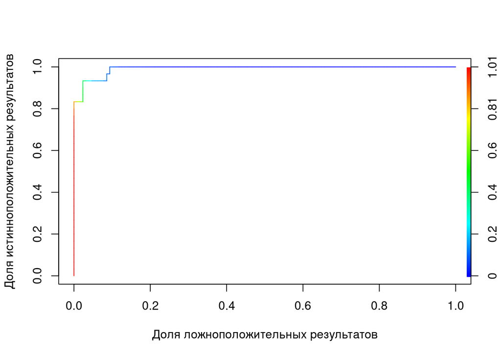

$AUC = 0.9916667 (95\% CI = 0.9820111 - 1.00)$

Специфичность, чувствительность и точность модели

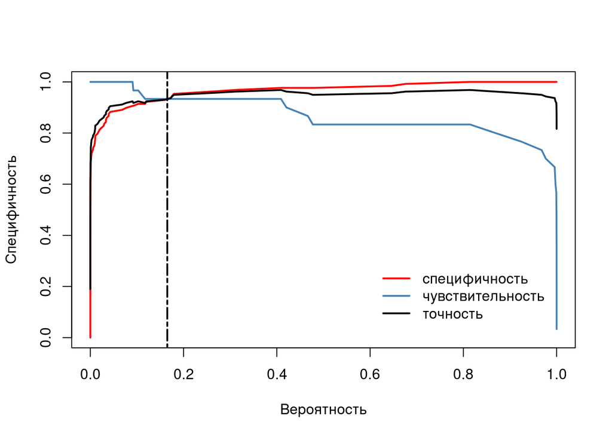

Вертикальная линия отмечает оптимальное пороговое значение вероятности (0.165) для выбранной модели - это та точка, где сходтся значения специфичности, чувствительности и точности (аккуратности) нашей модели. То есть, это то значение веротяности получить ТФ, выше которого мы считаем, что ТФ будет (то есть формула дает нам предсказание “да, фиброз будет”).

### Регрессионная модель Fscan

```
##
## Call:
## glm(formula = Fscan.hard ~ ., family = "binomial", data = for.reg2[complete.cases(for.reg2),
##     c(1:3, 6)])
##
## Deviance Residuals:
##     Min       1Q   Median       3Q      Max
## -2.4221  -0.6349  -0.3929   0.3574   2.8802
##
## Coefficients:
##              Estimate Std. Error z value Pr(>|z|)
## (Intercept) -3.349464   0.900526  -3.719  0.00020 ***
## GG          -1.342916   0.461638  -2.909  0.00363 **
## A2M          1.653694   0.331322   4.991    6e-07 ***
## GGT          0.007292   0.003150   2.315  0.02064 *
## ---
## Signif. codes:  0 '***' 0.001 '**' 0.01 '*' 0.05 '.' 0.1 ' ' 1
##
## (Dispersion parameter for binomial family taken to be 1)
##
##     Null deviance: 185.60  on 155  degrees of freedom
## Residual deviance: 125.76  on 152  degrees of freedom
## AIC: 133.76
##
## Number of Fisher Scoring iterations: 5
```

Полученная регрессионная модель выглядит так:

$log(odds(ТФ)) = -3.35 - 1.34*GG + 1.65*A2M + 0.007*GGT$, где

ТФ - тяжелый фиброз (по фиброскану).

Проверка эффективности модели - ROC и AUC

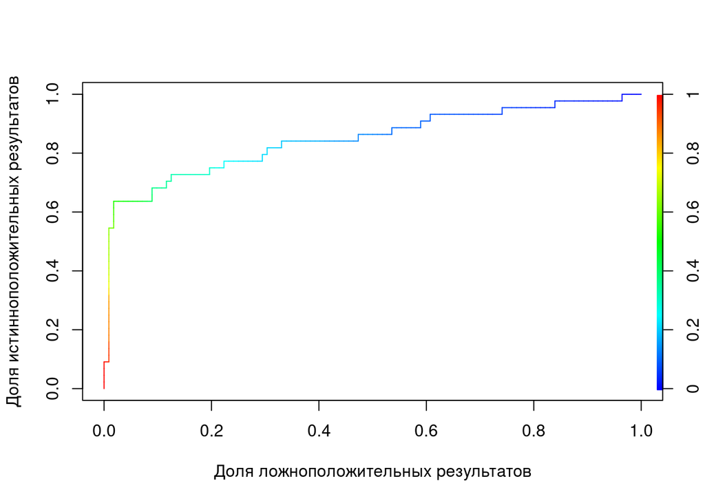

$AUC = 0.8461851 (95\% CI = 0.7679265 - 0.9244437)$

Специфичность, чувствительность и точность модели

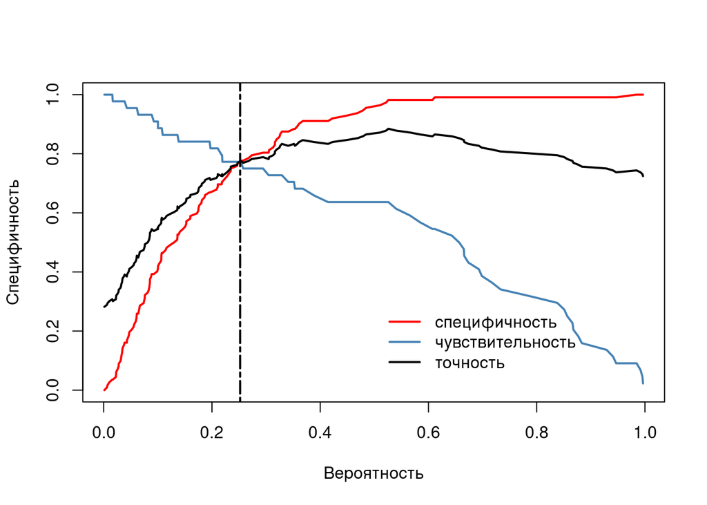

Вертикальная линия отмечает оптимальное пороговое значение вероятности (0.252) для выбранной модели. Пояснения аналогичные.